# Prosjektoppgave 1005 - Vår 2022

Kandidatnr.: 61

Begynner med å laste inn pakkene jeg vil bruke.

```r
library(dplyr)
library(tidyverse)
library(lubridate)
library(data.table)
library(microbenchmark)
library(purrr)
library(fs)
```

## OPPGAVE 1

I denne oppgaven skal jeg slå sammen 6 datasett til et stort et.

Laster først inn oppgavens datasett.

```r
store_attributes <- read_csv('https://data.mendeley.com/public-files/datasets/6htjnfs78b/files/26afd5e7-90b1-4301-ac5e-5905b38c4ec2/file_downloaded')

county_crime <- read_csv('https://data.mendeley.com/public-files/datasets/6htjnfs78b/files/3691994e-2874-4ee6-b215-12e130c96175/file_downloaded')

county_demographic <- read_csv('https://data.mendeley.com/public-files/datasets/6htjnfs78b/files/527e7486-7233-460a-99e0-3529b7cd7d49/file_downloaded')

county_employment <- read.csv('https://data.mendeley.com/public-files/datasets/6htjnfs78b/files/846ac757-721e-4fd9-a414-5871f60de093/file_downloaded')

weekly_sales <- read.csv('https://data.mendeley.com/public-files/datasets/6htjnfs78b/files/b963fdd1-0df9-4257-bd62-65256ec9d57c/file_downloaded')

weekly_weather <- read.csv('https://data.mendeley.com/public-files/datasets/6htjnfs78b/files/b8708b3c-c5e8-456e-83f4-9f23f472a840/file_downloaded')
```

Bruker mutate til å lage dato variabel i weekly_weather og weekly_sales.

```r
weekly_weather <- weekly_weather %>%
  mutate(Weather_Date = as.Date(Weather_Date, "%d/%m/%Y"))

weekly_sales <- weekly_sales %>%
  mutate(Date = as.Date(Date, "%m/%d/%Y"))
```

Endrer her noen navn på variabler for å skape felles variabelnavn på tvers av datasettene. Dette gjør jeg for å senere kunne slå sammen datasettene til ett. Jeg lager også variablene monthly_rent_estimate og weekly_rent_estimate i store_attributes med hjelp av mutate.

```r
store_attributes <- store_attributes %>%
  rename(Store_num = Store_Num,
         Weather_Station = Store_Weather_Station,
         County_Name = Store_County) %>%
  mutate(monthly_rent_estimate = Annual_Rent_Estimate / 12,
         weekly_rent_estimate = Annual_Rent_Estimate / 52)

weekly_weather <- weekly_weather %>%
  rename(Date = Weather_Date)

county_employment <- county_employment %>%
  rename(County_Name = ï..County_Name)
```

Slår sammen de 6 datasettene en etter en med hjelp av felles variabelnavn. Jeg bruker merge og left_join til dette formålet.

```r
CrimeDemo <- merge(county_crime, county_demographic, by = 'County_Name')

CrimeDemoEmp <- merge(CrimeDemo, county_employment, by = 'County_Name')

CrimeDemoEmpAtt <- merge(CrimeDemoEmp, store_attributes, by = 'County_Name')

CrimeDemoEmpAttSales <- merge(CrimeDemoEmpAtt, weekly_sales, by = 'Store_num')


alldata <- CrimeDemoEmpAttSales %>%
  left_join(weekly_weather, by = c('Date' = 'Date', 'Weather_Station' = 'Weather_Station'))
```

## OPPGAVE 2

Jeg skal nå lage en ukentlig salgsrapport for en av utsalgene i datasettet. Jeg velger å gå for Littletown StripMall (storenumber 9) i Appleton County.

For en ukentlig salgsrapport tenker jeg at det er lurt å se på hvilke produkter som selger mest (bestselgerne). Dette fordi at dette er varene som trekker kunder og kan bidra til høy omsetning på grunn av sin drakraft.

Det er også relevant å se på hvilke produkter som står for høyest profitt fordi dette er de produktene som drar lasset rent tallmessig når det kommer til omsetning.

Jeg tenker også at det er fornuftig å sammenligne noen tall med de foregående ukene.

Jeg begynner med å lage nye datasett, “ukentlig_salgsrapport”, hvor jeg velger ut relevant data fra ‘alldata’ til denne oppgaven. Jeg bruker i hovedsak filter og select til dette formålet.

```r
Ukentlig_Salgsrapport <- alldata %>%
  filter(Store_num == 9, Date == '2013-01-06') %>%
  select(Date ,County_Name, Store_City, Store_Name, Store_Location, Store_num, Annual_Rent_Estimate, INV_NUMBER, Description,
         Price, Sold, Del, Sales, Tot_Sls, Unit_Cost, Cost, Cost_Percent, Margin, Profit)


Ukentlig_Salgsrapport_2 <- alldata %>%
  filter(Store_num == 9, Date == '2012-12-30') %>%
  select(Date ,County_Name, Store_City, Store_Name, Store_Location, Store_num, Annual_Rent_Estimate, INV_NUMBER, Description,
         Price, Sold, Del, Sales, Tot_Sls, Unit_Cost, Cost, Cost_Percent, Margin, Profit)

Ukentlig_Salgsrapport_3 <- rbind(Ukentlig_Salgsrapport_2, Ukentlig_Salgsrapport)

Ukentlig_Salgsrapport_4 <- alldata %>%
  filter(Store_num == 9, Date == '2012-12-23') %>%
  select(Date ,County_Name, Store_City, Store_Name, Store_Location, Store_num, Annual_Rent_Estimate, INV_NUMBER, Description,
         Price, Sold, Del, Sales, Tot_Sls, Unit_Cost, Cost, Cost_Percent, Margin, Profit)

Ukentlig_Salgsrapport_5 <- rbind(Ukentlig_Salgsrapport_4, Ukentlig_Salgsrapport_3)
```

### Plot med bestselgerne i Littletown StripMall

Under har jeg laget et bar plot for bestselgerne i Littletown. Jeg filtrer Sold >= 50 for å få de mest solgte.

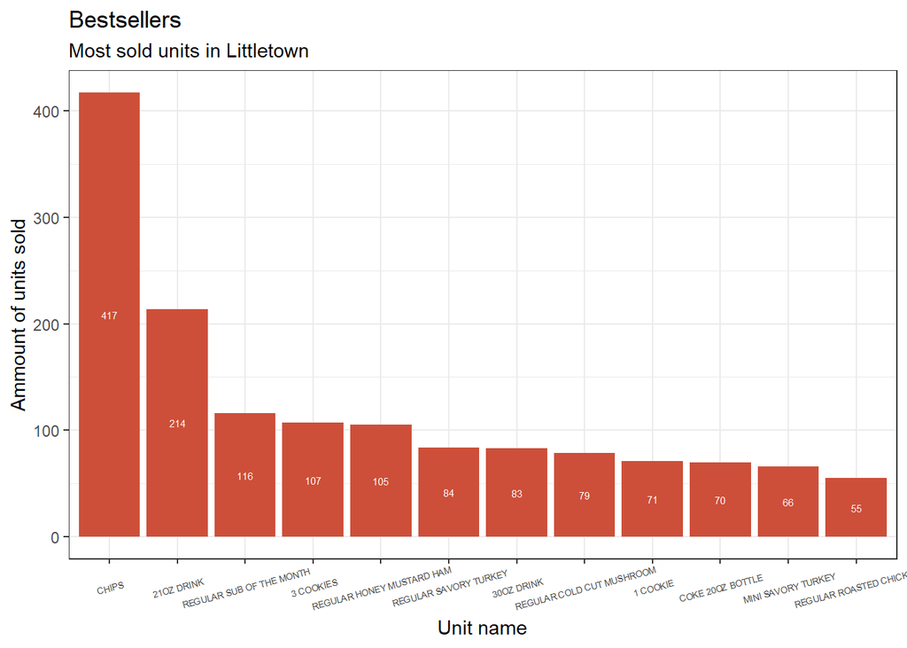

```r
Ukentlig_Salgsrapport %>%
  filter(Date == '2013-01-06', Sold >= 50) %>%
  ggplot(aes(x= reorder(Description,-Sold), y = Sold)) +
  geom_bar(stat="identity", fill="tomato3") +
  labs(title="Bestsellers",
       subtitle="Most sold units in Littletown")+
  ylab('Ammount of units sold')+
  xlab('Unit name')+
  geom_text(aes(label=Sold), position = position_stack(vjust= 0.5),
            colour = "white", size = 2)+
  theme_bw()+
  theme(axis.text.x = element_text(angle=15, vjust=0.6, size = 5))
```

Vi ser at chips er soleklar vinner etterfulgt av drikke. Dette er viktige varer. Kan prisen skyves opp på disse varene vil det kunne utgjøre en stor forskjell på omsetningen.

### Plot for varene med størst profitt i Littletown StripMall

Under har jeg laget et bar plot for varene med høyest profitt i Littletown.

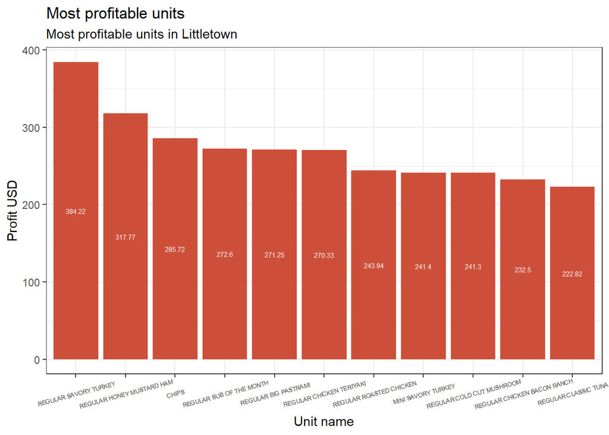

```r
Ukentlig_Salgsrapport %>%
  filter(Date == '2013-01-06', Profit >= 200) %>%
  ggplot(aes(x= reorder(Description,-Profit), y = Profit)) +
  geom_bar(stat="identity", fill="tomato3") +
  labs(title="Most profitable units",
       subtitle="Most profitable units in Littletown")+
  ylab('Profit USD')+
  xlab('Unit name')+
  geom_text(aes(label=Profit), position = position_stack(vjust= 0.5),
            colour = "white", size = 2)+
  theme_bw()+
  theme(axis.text.x = element_text(angle=15, vjust=0.6, size = 5))
```

### Samme plot med foregående uke stacked

Her har jeg lagt til forrige ukes varer med størst profitt.

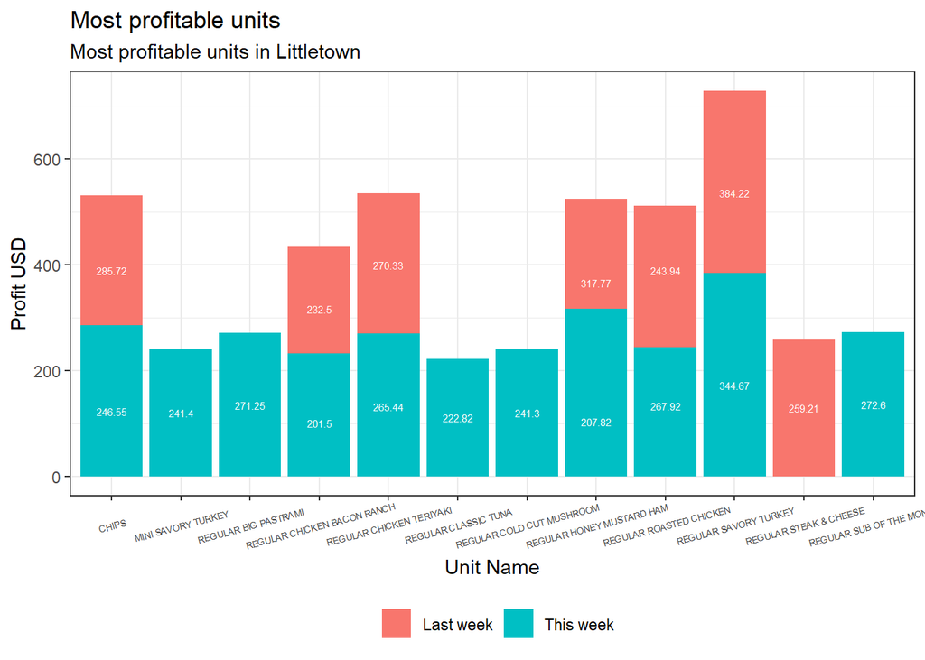

```r
labs <- expression('Last week', 'This week')


Ukentlig_Salgsrapport_3 %>%
  filter(Profit >= 200) %>%
  ggplot(aes(x = Description, y = Profit)) +
  geom_bar(stat = 'identity', aes(fill = factor(Date)))+
  labs(title="Most profitable units",
       subtitle="Most profitable units in Littletown")+
  geom_text(aes(label=Profit), position = position_stack(vjust= 0.5),
            colour = "white", size = 2)+
  theme_bw()+
  theme(axis.text.x = element_text(angle=15, vjust=0.6, size = 5))+
  theme(legend.position="bottom")+
  labs(fill = '', x = 'Unit Name', y = 'Profit USD')+
  scale_fill_discrete(labels=labs)
```

Vi ser at nåværende uke har flere varer med profittverdi over 200, enn hva forrige uke hadde.

### Plot som vise profitt for de tre siste ukene

Til slutt lager jeg et plot som sammenligner de siste tre ukenes totale profitt.

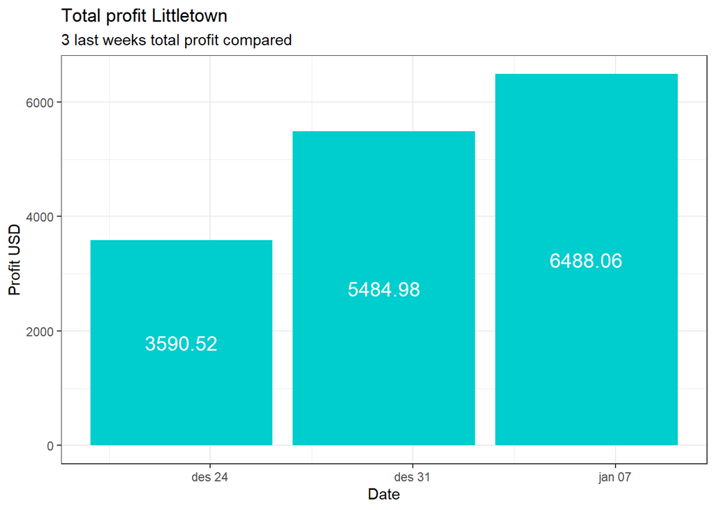

```r
week_labels <- c("Two weeks ago",'Last week', 'This week')


Ukentlig_Salgsrapport_5 %>%
  group_by(Date) %>%
  summarise(Total_Profit = sum(Profit)) %>%
  ggplot(aes(x = Date, y = Total_Profit)) +
  geom_bar(stat="identity", fill="cyan3") +
  labs(title="Total profit Littletown",
       subtitle='3 last weeks total profit compared')+
  ylab('Profit USD')+
  geom_text(aes(label=Total_Profit), position = position_stack(vjust= 0.5),
            colour = "white", size = 5)+
  theme_bw()
```

Vi ser at uken vi har fokus på, tick-navn “jan 07”, er uken med best profitt. Det kan være derfor vi så flere varer med profitverdi over 200 på denne uken i forrige graf.

## OPPGAVE 3

I denne oppgaven skal jeg lage en månedlig salgsrapport med alle utsalgene. Jeg har valgt å fokusere på September 2012.

Jeg starter med å lage et nytt datasett hvor jeg henter relevante tall for denne oppgaven fra ‘alldata’. Jeg filtrer ut september 2012 og tar med de relevante variablene.

```r
maanedlig_salgsrapport <- alldata %>%
  filter(Year == 2012, Month >= 9 & Month < 10) %>%
  select(Date, Year, Month, Day, County_Name, Store_City, Store_Name, Store_Location, Store_num, Annual_Rent_Estimate, INV_NUMBER, Description,
         Price, Sold, Del, Sales, Tot_Sls, Unit_Cost, Cost, Cost_Percent, Margin, Profit)
```

### Linje plot for alle utsalgene September 2012

Under har jeg laget et linje plot som viser profitt for alle utsalgene i løpet av 5 observasjoner i septemer 2012.

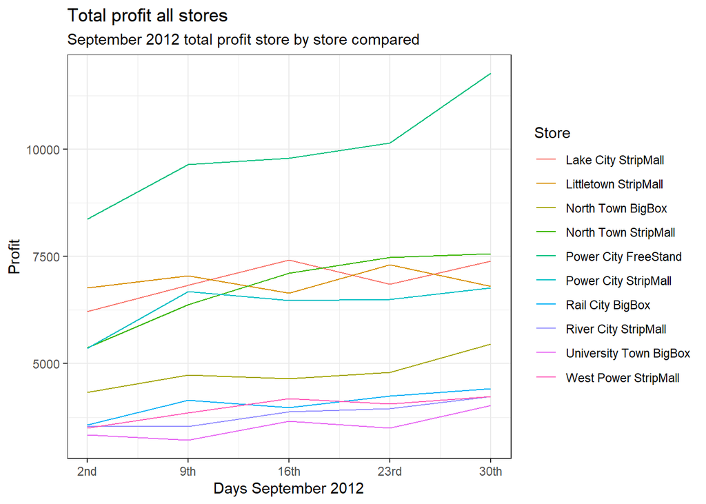

```r
maanedlig_salgsrapport %>%
  group_by(Day, Store_Name) %>%
  summarise(Total_profit_daily = sum(Profit)) %>%
  ggplot(aes(x = Day, y = Total_profit_daily, col = Store_Name)) +
  geom_line() +
  scale_x_continuous(breaks = c(2,9,16,23,30),
                     labels = c("2nd",'9th', '16th', '23rd', '30th'))+
  labs(title="Total profit all stores",
       subtitle='September 2012 total profit store by store compared',
       col = 'Store')+
  ylab('Profit')+
  xlab('Days September 2012')+
  theme_bw()
```

Vi ser at Power City FreeStand er utsalget som gjør det klart best.

### Bar plot for alle utsalgene September 2012

Under har jeg laget et bar plot med samlet profitt for alle utsalgene September 2012.

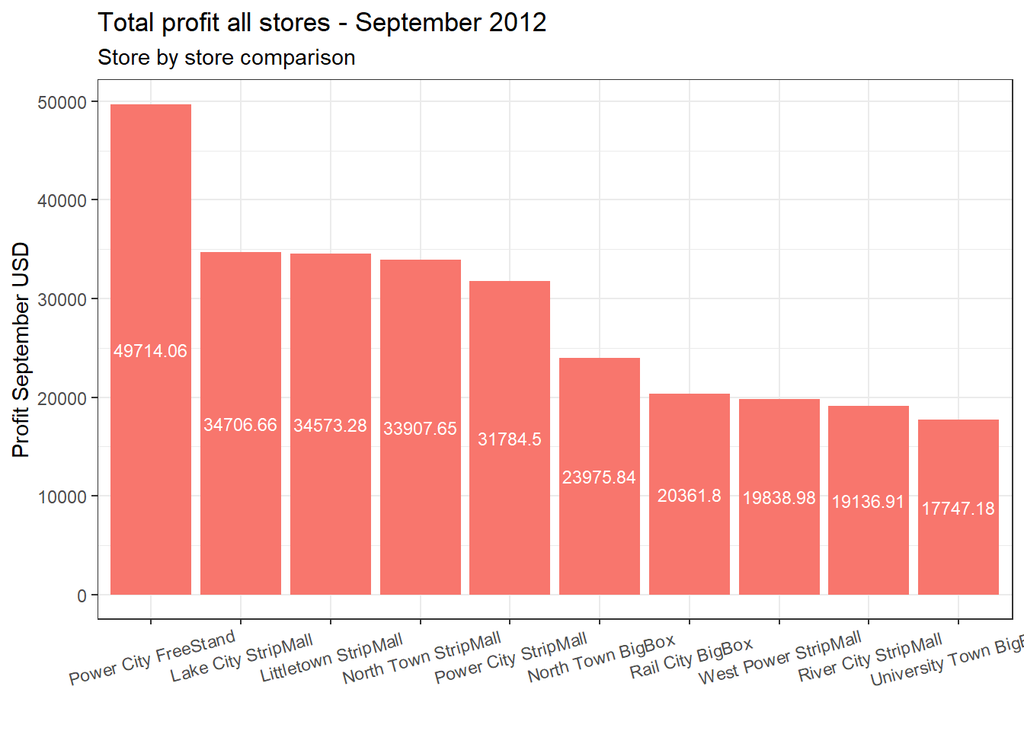

```r
maanedlig_salgsrapport %>%
  group_by(Month, Store_Name) %>%
  summarise(Total_profit_month = sum(Profit)) %>%
  ggplot(aes(x= reorder(Store_Name,-Total_profit_month), y = Total_profit_month)) +
  geom_col(aes(fill = 'red'), show.legend = FALSE) +
  labs(title="Total profit all stores - September 2012",
       subtitle='Store by store comparison',
       col = 'Store')+
  ylab('Profit September USD')+
  xlab('')+
  geom_text(aes(label=Total_profit_month), position = position_stack(vjust= 0.5),
            colour = "white", size = 3)+
  theme_bw()+
  theme(axis.text.x = element_text(angle=15, vjust=0.6))
```

Jeg ønsket å finne ut hvilken vare som utgjorde størst profitt for hver enkelt utsalg i september.

```r
maanedlig_salgsrapport %>%
  select(Store_Name, Month, Description, Profit) %>%
  group_by(Store_Name) %>%
  filter(Profit == max(Profit))
```

```
## # A tibble: 10 x 4
## # Groups:   Store_Name [10]
##    Store_Name             Month Description              Profit
##    <chr>                  <int> <chr>                     <dbl>
##  1 Power City FreeStand       9 REGULAR SUB OF THE MONTH  1948.
##  2 West Power StripMall       9 REGULAR SUB OF THE MONTH   927.
##  3 Power City StripMall       9 REGULAR SUB OF THE MONTH  1089.
##  4 Littletown StripMall       9 REGULAR SUB OF THE MONTH  1354.
##  5 River City StripMall       9 REGULAR SUB OF THE MONTH   663.
##  6 Rail City BigBox           9 REGULAR SUB OF THE MONTH   834.
##  7 Lake City StripMall        9 REGULAR SUB OF THE MONTH   952.
##  8 North Town StripMall       9 REGULAR SUB OF THE MONTH  1787.
##  9 North Town BigBox          9 REGULAR SUB OF THE MONTH  1108.
## 10 University Town BigBox     9 REGULAR SUB OF THE MONTH   487.
```

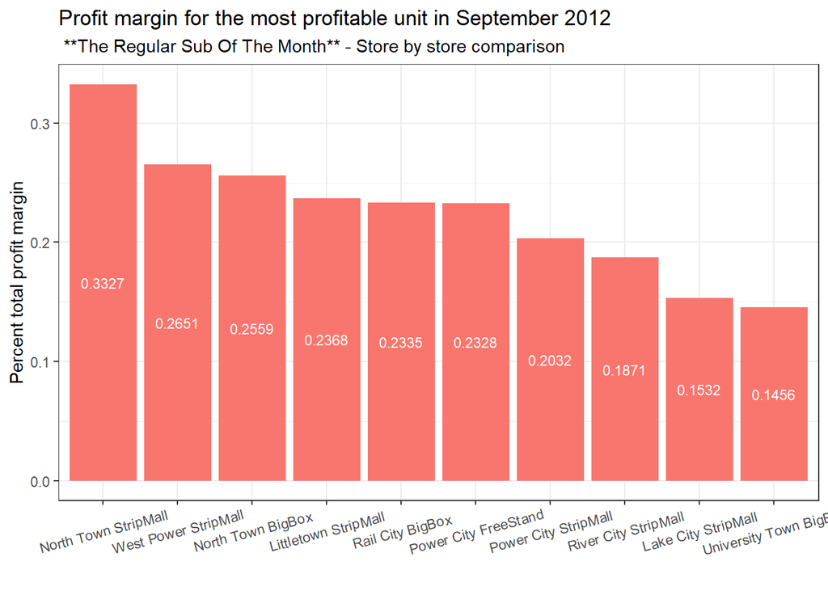

```r
maanedlig_salgsrapport %>%
  select(Store_Name, Month, Description, Profit, Margin) %>%
  group_by(Store_Name) %>%
  filter(Margin == max(Margin)) %>%
  ggplot(aes(x= reorder(Store_Name,-Margin), y = Margin)) +
  geom_col(aes(fill = 'red'), show.legend = FALSE) +
  labs(title='Profit margin for the most profitable unit in September 2012',
       subtitle=' **The Regular Sub Of The Month** - Store by store comparison',
       col = 'Store')+
  ylab('Percent total profit margin')+
  xlab('')+
  geom_text(aes(label=Margin), position = position_stack(vjust= 0.5),
            colour = "white", size = 3)+
  theme_bw()+
  theme(axis.text.x = element_text(angle=15, vjust=0.6))
```

## OPPGAVE 4

Nå skal vi prøve å hjelpe bedriften med å finne nyttig informasjon som kan hjelpe dem å velge lokasjon for et nytt utsalg.

### Barplot som viser korrelasjon mellom profitt og beliggenhet

Har det noe å si for utsalgene om de blir plassert i nærheten av en skole?

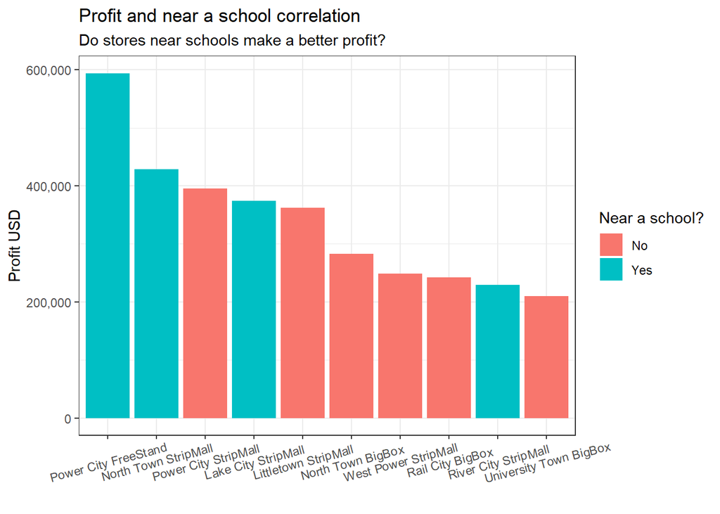

```r
alldata %>%
  select(Store_Name, Profit, Store_Near_School) %>%
  group_by(Store_Name, Store_Near_School) %>%
  summarise(Profit = sum(Profit)) %>%
  ggplot(aes(x = reorder(Store_Name,-Profit), y = Profit))+
  geom_col(aes(fill = Store_Near_School))+
  scale_y_continuous(labels = scales::comma)+ # thousands
  labs(title="Profit and near a school correlation",
       subtitle='Do stores near schools make a better profit?',
       fill = 'Near a school?')+
  ylab('Profit USD')+
  xlab('')+
  theme_bw()+
  theme(axis.text.x = element_text(angle=15, vjust=0.6))
```

### Barplot som viser profitt og county korrelasjon

Hvilke countys bør vurders?

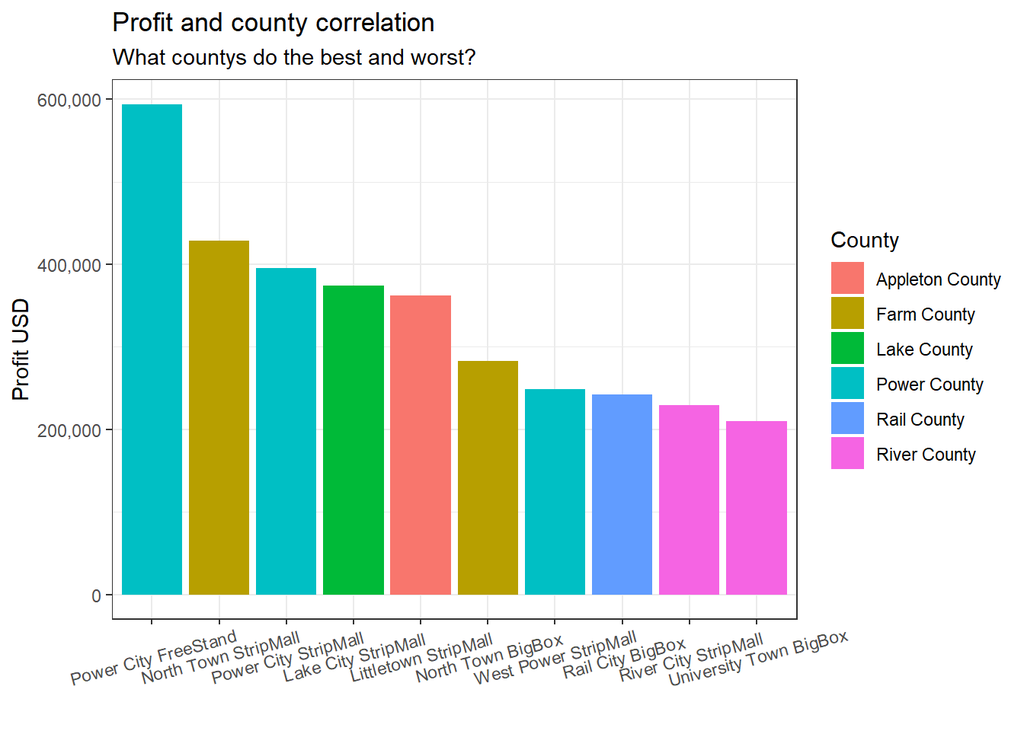

```r
alldata %>%
  select(County_Name, Store_Name, Profit) %>%
  group_by(Store_Name, County_Name) %>%
  summarise(Profit = sum(Profit)) %>%
  ggplot(aes(x = reorder(Store_Name,-Profit), y = Profit))+
  geom_col(aes(fill = County_Name))+
  scale_y_continuous(labels = scales::comma)+
  labs(title="Profit and county correlation",
       subtitle='What countys do the best and worst?',
       fill = 'County')+
  ylab('Profit USD')+
  xlab('')+
  theme_bw()+
  theme(axis.text.x = element_text(angle=15, vjust=0.6))
```

Vi ser at power county gjør det veldig bra. River county er helt i den andre enden, og bør vurderes å legges ned med mindre bedriften kan løse problemene til disse svake utsalgene.

### Barplot som viser korrleasjon mellom profitt og drive through

Bør den nye lokasjonen ha drive through? Er det verdt det?

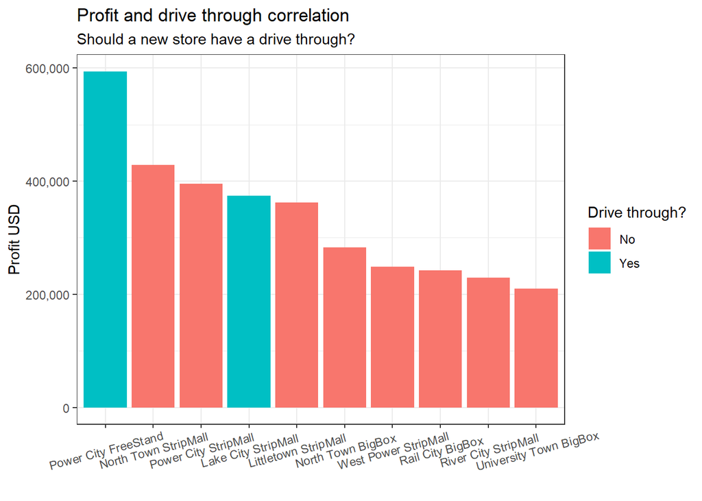

```r
alldata %>%
  select(Store_Name, Profit, Store_Drive_Through, Store_Competition_Fastfood) %>%
  group_by(Store_Name, Store_Drive_Through, Store_Competition_Fastfood) %>%
  summarise(Profit = sum(Profit)) %>%
  ggplot(aes(x = reorder(Store_Name,-Profit), y = Profit))+
  geom_col(aes(fill = Store_Drive_Through))+
  scale_y_continuous(labels = scales::comma)+
  labs(title="Profit and drive through correlation",
       subtitle='Should a new store have a drive through?',
       fill = 'Drive through?')+
  ylab('Profit USD')+
  xlab('')+
  theme_bw()+
  theme(axis.text.x = element_text(angle=15, vjust=0.6))
```

### Sluttvurdering

Jeg har bare tatt med grafer som har vist relevant positiv korrelasjon.

Jeg vil anbefale at bedriften vurderer å lage et nytt utsalg i Power county, samtidig som de bør vurdere å legge ned utsalgene i River county.